```python
%matplotlib inline

%load_ext autoreload
%autoreload 2

from interface import *

from cycler import cycler
from matplotlib.ticker import AutoMinorLocator

def plot_config():
    fsize = 14 # a quarter of the paper width: 20 pt; half of the paper width: 12
    font = {'size' : fsize, 'family' : 'serif'}
    color_cycle = ['r', 'b', 'g', 'c', 'm', 'y', 'k']
    linestyle_cycle = ['-', '--', '-.', ':', (0, (5, 2, 5, 2)), (0, (10, 2, 5, 2, 2, 2)), (0, (12, 2, 2, 2))]
    marker_cycle = ['o', 'd', 'v', '^', '<', '>', '*']

    mpl.rc('font', **font)
    mpl.rc('xtick', labelsize = 10, direction = 'in', top   = True)
    mpl.rc('ytick', labelsize = 10, direction = 'in', right = True)
    mpl.rc('xtick.major', size = 5, width = 1)
    mpl.rc('ytick.major', size = 5, width = 1)
    mpl.rc('xtick.minor', size = 3, width = 0.7, visible = True)
    mpl.rc('ytick.minor', size = 3, width = 0.7, visible = True)

    mpl.rc('lines', linewidth=2, markersize=6, color='r')
    # mpl.rc('lines', linestyle = 'solid')
    mpl.rc('axes', labelpad = 0, prop_cycle=(cycler('color', color_cycle) + cycler('linestyle', linestyle_cycle) + cycler('marker', marker_cycle)))
    mpl.rc('legend', fontsize = 12, labelspacing = 0.05, handletextpad=0.4, frameon=False, handlelength=2.1)

    mpl.rc('figure', dpi = 100, figsize = (4, 4))
    mpl.rc('figure.subplot', bottom = 0.15, top = 0.9, left = 0.15, right = 0.9)

    return
plot_config()
```

```
The autoreload extension is already loaded. To reload it, use:
  %reload_ext autoreload
```

# Define functions and variables

```python
afs_data = r'\\afs\ifh.de\group\pitz\data'

workdir = os.path.join(afs_data, 'lixiangk', 'sim', '2020', 'interface', 'tutorials')
os.chdir(workdir)

I2B = lambda I: -(0.0000372+0.000588*I)
B2I = lambda B: (-B-0.0000372)/0.000588

field_maps = os.path.join('..', 'examples','field-maps')

BSA = 1.0
sigma_x = sigma_y = BSA/4.

phi_gun, phi_booster = 0, 0

MaxE_gun = 60
MaxE_booster = 12.

Imain = 372; MaxB = I2B(Imain)
```

# Generate input files for `Generator` and `Astra`

`Generator` uses only one namelist called `Input`. Therefore, one just needs to give all the variables and their values when initializing it. The name of variables are case insensitive.

```python
# Define Input module
generator = Generator1(FNAME = 'beam.ini', IPart = 50000, Species = 'electrons', Q_total = -4.,\
                      Ref_Ekin = 0.0e-6, LE = 0.55e-3, dist_pz = 'i',
                      Dist_z = 'p', Lt = 21.5e-3, rt = 2e-3, Cathode = True,\
                      Dist_x = 'r', sig_x = sigma_x, Dist_px = 'g', Nemit_x = 0,\
                      Dist_y = 'r', sig_y = sigma_x, Dist_py = 'g', Nemit_y = 0)
```

After the initialization, one can update the values of variable by calling the `Module.set` method. If the specified variable doesn't exist, this method will add the new variable.

```python
generator.set(Q_total = -0.1, Ipart = 200000)
print(generator.output)
```

```
&INPUT
 FNAME='beam.ini'
 IPART=200000
 SPECIES='electrons'
 Q_TOTAL=-0.1
 REF_EKIN=0.0
 LE=0.00055
 DIST_PZ='i'
 DIST_Z='p'
 LT=0.0215
 RT=0.002
 CATHODE=True
 DIST_X='r'
 SIG_X=0.25
 DIST_PX='g'
 NEMIT_X=0
 DIST_Y='r'
 SIG_Y=0.25
 DIST_PY='g'
 NEMIT_Y=0
 LPROMPT=False
&END
```

`Astra` has more than one namelists, therefore one needs to initialize them one by one. Similarly, one can update any variable with the `Namelist.set` method. Note that in some namelist, one variable can be assigned several values, for instance, `MaxE` in `Cavity`. In such a case, the variable must be assigned with a `list`, e.g., `MaxE = [60, 12]`.

```python
# Define namelists for Astra
newrun = Namelist('Newrun', Run = 1, Head = 'PITZ beam line simulation',
                Distribution = 'beam.ini', Auto_Phase = True, Track_All = True,
                check_ref_part = False, Lprompt = False)
newrun.set(Run = 1, Track_All = False)

charge = Namelist('Charge', LSPCH = True, Nrad = 50, Nlong_in = 50, N_min = 10,
                Max_scale = 0.05, Max_count = 20)

gun_profile = os.path.join(field_maps, 'gun42cavity.txt')
booster_profile = os.path.join(field_maps, 'CDS14_15mm.txt')
File_Efield = [gun_profile, booster_profile]

cavity = Namelist('Cavity', LEfield = True, File_Efield = File_Efield,
                MaxE = [MaxE_gun, MaxE_booster], C_pos = [0., 2.675],
                Nue = [1.3, 1.3], Phi = [phi_gun, phi_booster])

solenoid_profile = os.path.join(field_maps, 'gunsolenoidsPITZ.txt')
solenoid = Namelist('Solenoid', LBfield = True, File_Bfield = [solenoid_profile],
                  MaxB = MaxB, S_pos = [0.])

output = Namelist('Output', Zstart = 0, Zstop = 5.28, Zemit = 200, Zphase = 2, RefS = True,
                EmitS = True, PhaseS = True, TrackS = True, LandFS = True)

aperture_profile = os.path.join(field_maps, 'app1.txt')
aperture = Namelist('Aperture', LApert = True, File_Aperture = [aperture_profile])

quadrupole = Namelist('Quadrupole', Lquad = True)
```

Afterwards, one can create an `Astra` instance and add all the defined modules to it by a `list`. Finally, call the `write` method to output files for simulations.

```python
astra = Astra()
astra.add_modules([newrun, charge, cavity, solenoid, output, aperture])

# Write inputs file
generator.write('gen.in')
astra.write('ast.in')
```

## Run `Astra` within `python`

One can also start `Generator` and `Astra` within `python`, but should add the `path to astra/generator` to the system variable `PATH` first.

In the current example, the Track_All is turned off, therefore the simulation ends very soon.

```python
generator.run('gen.in')
astra.run('ast.in')
```

```
Is finished? False
Is finished? False
```

```
0
```

# Post-processing

## Use `BeamDiagnostics` for statistics of a distribution

```
            avg_z:   -7.291834E-11 m
          nemit_x:    2.117895E-01 um
          nemit_y:    2.117895E-01 um
            std_x:    2.500063E-01 mm
            std_y:    2.500062E-01 mm
            std_z:    1.880402E+00 mm
             Ekin:    5.500297E-07 MeV
         std_Ekin:    1.960970E-07 keV
          nemit_z:    1.034277E-03 keV mm
              Q_b:   -3.999520E-09 C
            avg_x:   -1.498676E-08 m
            avg_y:   -1.499066E-08 m
          alpha_x:   -4.553884E-03
           beta_x:    6.783113E-07 m
          gamma_x:    1.474280E+06 m^-1
           emit_x:    9.214521E-02 m
          alpha_y:   -2.516995E-03
           beta_y:    1.581827E-06 m
          gamma_y:    6.321846E+05 m^-1
           emit_y:    3.951326E-02 m
         cor_Ekin:   -1.397973E-10 keV
     loss_cathode:    0.000000E+00
    loss_aperture:    0.000000E+00
             FWHM:    6.445196E+00 mm
              NoP:    5.000000E+04
               I1:    1.865588E+02 A
               I0:    1.865588E+02 A
          cov_xxp:    4.196186E+02 mmmrad
          cov_yyp:    9.945468E+01 mmmrad
```

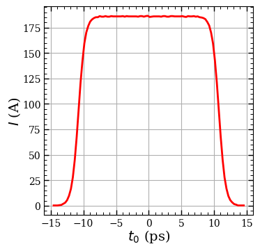

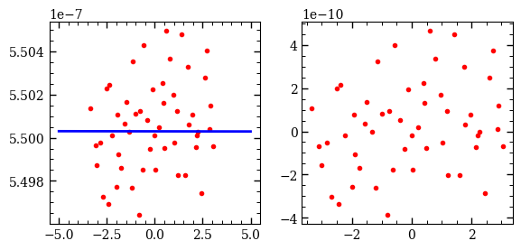

```python
# Here, the plot option is used for current profile
diag = BeamDiagnostics(fname = 'beam.ini', plot = True)
diag.demo()
```

One can get the specified parameter by its name:

```python
print(diag.avg_z)
print(diag.nemit_x)
```

```
-7.291833594409778e-11
0.2117895322010252
```

## Plot phase spaces

```
extent:  -1 1 -1 1
extent:  -0.7498799849600281 0.7498800150399721 -1.1249025350452602 1.1249024649547401
extent:  -6.614246125649087 6.614245979829915 -0.00018741016421236007 0.00093718483578764
```

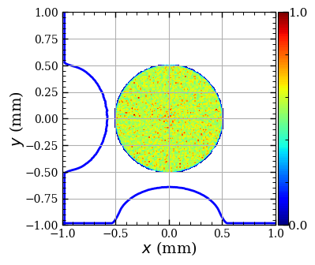

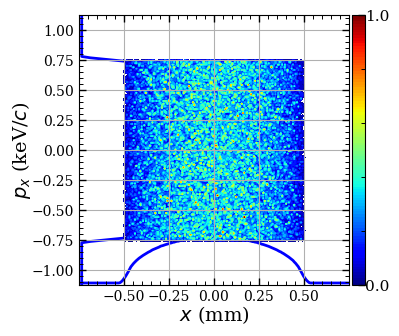

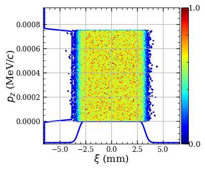

```python
fname = 'beam.ini'
fig_ext = '.png'

xmax = ymax = 1

plot2d_xy( fname, fig_ext = fig_ext, vmin = 0.01, bins = (200, 200), extent = [-xmax, xmax, -ymax, ymax])
plot2d_xpx(fname, fig_ext = fig_ext, vmin = 0.01, bins = (200, 200))
plot2d_zpz(fname, fig_ext = fig_ext, vmin = 0.01, bins = (200, 200))
```